# PSTAT 131 HW 3

Ezra Aguimatang

2022-10-31

## Classification

For this assignment, we will be working with part of a [Kaggle data set](https://www.kaggle.com/c/titanic/overview) that was the subject of a machine learning competition and is often used for practicing ML models. The goal is classification; specifically, to predict which passengers would survive the [Titanic shipwreck](https://en.wikipedia.org/wiki/Titanic).

Load the data from `data/titanic.csv` into *R* and familiarize yourself with the variables it contains using the codebook (`data/titanic_codebook.txt`).

Notice that `survived` and `pclass` should be changed to factors. When changing `survived` to a factor, you may want to reorder the factor so that *“Yes”* is the first level.

Make sure you load the `tidyverse` and `tidymodels`!

*Remember that you’ll need to set a seed at the beginning of the document to reproduce your results.*

```r
titanic_df <- read.csv("131_HW_3_Data/titanic.csv", header=TRUE)
titanic_surv_fac_df <- factor(titanic_df$survived, levels=c("Yes", "No"))
head(titanic_surv_fac_df)
```

```
## [1] No  Yes Yes Yes No  No
## Levels: Yes No
```

```r
#titanic_fac_df <- factor(titanic_surv_fac_df$pclass, labels=c("3rd", "2nd", "1st"))
#head(titanic_fac_df)
```

### Question 1

Split the data, stratifying on the outcome variable, `survived.` You should choose the proportions to split the data into. Verify that the training and testing data sets have the appropriate number of observations. Take a look at the training data and note any potential issues, such as missing data.

Why is it a good idea to use stratified sampling for this data?

#### Solution 1:

```r
# sets the seed in order to reproduce results
set.seed(3435)

# creates an initial split of abalone data
titanic_split <- initial_split(titanic_df, prop=0.80, strata=survived)
titanic_split
```

```
## <Training/Testing/Total>
## <712/179/891>
```

```r
# creates the training split using 80% of the data
titanic_train <- training(titanic_split)
head(titanic_train, n=5)
```

```
##    passenger_id survived pclass                           name  sex age sib_sp
## 1             1       No      3        Braund, Mr. Owen Harris male  22      1
## 5             5       No      3       Allen, Mr. William Henry male  35      0
## 7             7       No      1        McCarthy, Mr. Timothy J male  54      0
## 8             8       No      3 Palsson, Master. Gosta Leonard male   2      3
## 14           14       No      3    Andersson, Mr. Anders Johan male  39      1
##    parch    ticket    fare cabin embarked
## 1      0 A/5 21171  7.2500  <NA>        S
## 5      0    373450  8.0500  <NA>        S
## 7      0     17463 51.8625   E46        S
## 8      1    349909 21.0750  <NA>        S
## 14     5    347082 31.2750  <NA>        S
```

```r
# creates the test split using the remaining 20% of the data
titanic_test <- testing(titanic_split)
head(titanic_test, n=5)
```

```
##    passenger_id survived pclass
## 6             6       No      3
## 9             9      Yes      3
## 12           12      Yes      1
## 13           13       No      3
## 26           26      Yes      3
##                                                         name    sex age sib_sp
## 6                                           Moran, Mr. James   male  NA      0
## 9          Johnson, Mrs. Oscar W (Elisabeth Vilhelmina Berg) female  27      0
## 12                                  Bonnell, Miss. Elizabeth female  58      0
## 13                            Saundercock, Mr. William Henry   male  20      0
## 26 Asplund, Mrs. Carl Oscar (Selma Augusta Emilia Johansson) female  38      1
##    parch    ticket    fare cabin embarked
## 6      0    330877  8.4583  <NA>        Q
## 9      2    347742 11.1333  <NA>        S
## 12     0    113783 26.5500  C103        S
## 13     0 A/5. 2151  8.0500  <NA>        S
## 26     5    347077 31.3875  <NA>        S
```

### Question 2

Using the **training** data set, explore/describe the distribution of the outcome variable `survived`.

#### Solution 2:

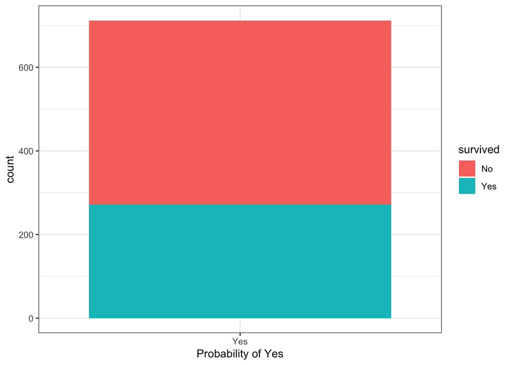

```r
# Question 2
ggplot(data=titanic_train, aes(x = "Yes", fill = survived)) +
  geom_histogram(stat="count") +
  theme_bw() +
  xlab("Probability of Yes")
```

### Question 3

Using the **training** data set, create a correlation matrix of all continuous variables. Create a visualization of the matrix, and describe any patterns you see. Are any predictors correlated with each other? Which ones, and in which direction?

#### Solution 3:

```r
# creates and plots correlation matrix of titanic training data
cor_titanic_train <- titanic_train %>%
  correlate()
```

```
## Non-numeric variables removed from input: `survived`, `name`, `sex`, `ticket`, `cabin`, and `embarked`
## Correlation computed with
## • Method: 'pearson'
## • Missing treated using: 'pairwise.complete.obs'
```

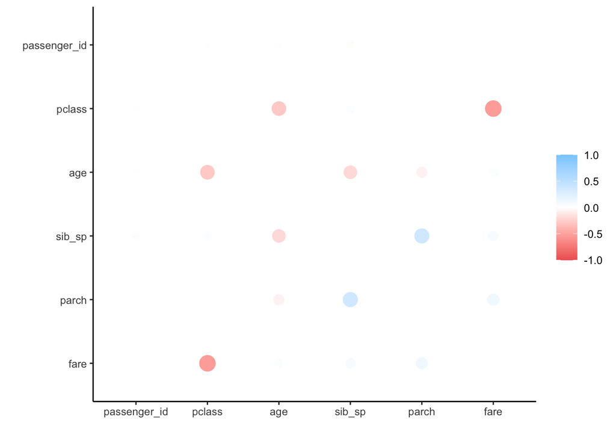

```r
rplot(cor_titanic_train)
```

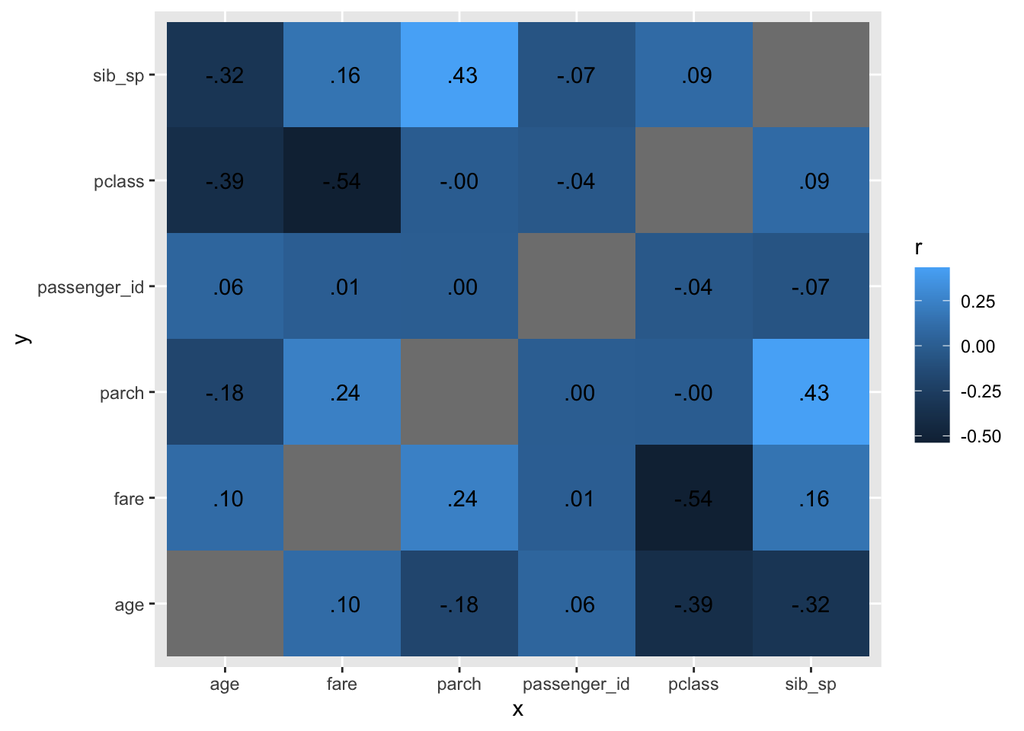

```r
# creates and plots heat map-style correlation of titanic training data
cor_titanic_train %>%
  stretch() %>%
  ggplot(aes(x, y, fill = r)) +
  geom_tile() +
  geom_text(aes(label = as.character(fashion(r))))
```

### Question 4

Using the **training** data, create a recipe predicting the outcome variable `survived`. Include the following predictors: ticket class, sex, age, number of siblings or spouses aboard, number of parents or children aboard, and passenger fare.

Recall that there were missing values for `age`. To deal with this, add an imputation step using `step_impute_linear()`. Next, use `step_dummy()` to **dummy** encode categorical predictors. Finally, include interactions between:

- Sex and passenger fare, and
- Age and passenger fare.

You’ll need to investigate the `tidymodels` documentation to find the appropriate step functions to use.

#### Solution 4:

```r
titanic_recipe_a <- recipe(survived ~ pclass + sex + age +
                           sib_sp + parch + fare, titanic_train) %>%
  step_impute_linear(age, impute_with = imp_vars(sib_sp)) %>%
  # choice of predictors to impute with is up to you
  step_dummy(all_nominal_predictors()) %>%
  step_interact(~ starts_with("sex"):age + age:fare)
```

### Question 5

Specify a **logistic regression** model for classification using the `"glm"` engine. Then create a workflow. Add your model and the appropriate recipe. Finally, use `fit()` to apply your workflow to the **training** data.

*Hint: Make sure to store the results of `fit()`. You’ll need them later on.*

#### Solution 5:

```r
log_reg <- logistic_reg() %>%
  set_engine("glm") %>%
  set_mode("classification")

log_wkflow_a <- workflow() %>%
  add_model(log_reg) %>%
  add_recipe(titanic_recipe_a)

log_fit_a <- fit(log_wkflow_a, titanic_train)
```

### Question 6

**Repeat Question 5**, but this time specify a linear discriminant analysis model for classification using the `"MASS"` engine.

```r
# Question 6
```

### Question 7

**Repeat Question 5**, but this time specify a quadratic discriminant analysis model for classification using the `"MASS"` engine.

```r
# Question 7
```

### Question 8

**Repeat Question 5**, but this time specify a naive Bayes model for classification using the `"klaR"` engine. Set the `usekernel` argument to `FALSE`.

```r
# Question 8
```

### Question 9

Now you’ve fit four different models to your training data.

Use `predict()` and `bind_cols()` to generate predictions using each of these 4 models and your **training** data. Then use the *accuracy* metric to assess the performance of each of the four models.

Which model achieved the highest accuracy on the training data?

#### Solution 9:

```r
predict(log_fit_a, new_data=titanic_train, type = "prob")
```

```
## # A tibble: 712 × 2
##    .pred_No .pred_Yes
##       <dbl>     <dbl>
##  1    0.879    0.121
##  2    0.929    0.0707
##  3    0.775    0.225
##  4    0.829    0.171
##  5    0.989    0.0109
##  6    0.273    0.727
##  7    0.875    0.125
##  8    0.421    0.579
##  9    0.798    0.202
## 10    0.551    0.449
## # … with 702 more rows
```

### Question 10

Fit the model with the highest training accuracy to the **testing** data. Report the accuracy of the model on the **testing** data.

Again using the **testing** data, create a confusion matrix and visualize it. Plot an ROC curve and calculate the area under it (AUC).

How did the model perform? Compare its training and testing accuracies. If the values differ, why do you think this is so?

```r
# Question 10
```

# NOT ENROLLED IN PSTAT 231

### Required for 231 Students

In a binary classification problem, let $p$ represent the probability of class label $1$, which implies that $1 - p$ represents the probability of class label $0$. The *logistic function* (also called the “inverse logit”) is the cumulative distribution function of the logistic distribution, which maps a real number *z* to the open interval $(0, 1)$.

### Question 11

Given that:

$$p(z)=\frac{e^z}{1+e^z}$$